# Chapter 1 - Data Visualization

## 7.1 - Exercises

**1 - What is the problem with this plot and how can you fix it?**

The problem is that stuff overlap, as there are only that many ctys and hwy combinations. This can be fixed by adding jitter.

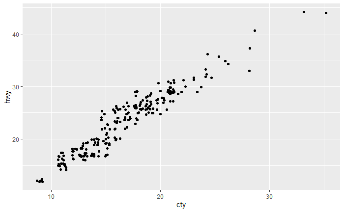

**2 - What parameters to geom_citter() control the amount of jittering?**

We will look at the documentations.

Height and width is added to jitter. By default this is 40% of the resolutinon of the data.

**3 - Compre and contrast geom_jitter with geom_count**

Lets make a geom count graph

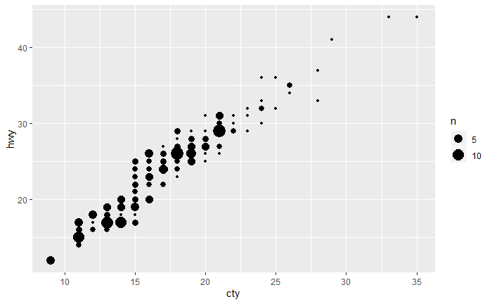

Geom count adds the count to the graph, increasing the size (or other variables) dependent of how many items are in that exact positon.

**4 - What is the default position adjustment for geom_boxplot? Create a visulization of mpg do demonstrate this**

Lets first look at the documentation.

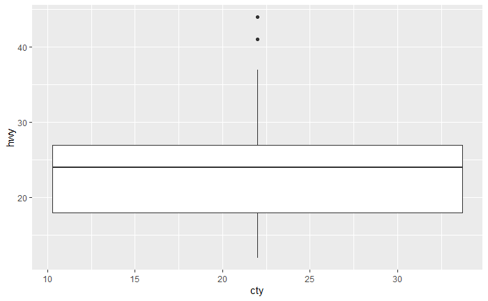

# 8 - Coordinate systems

## 8.1 - Notes

Coordinate systems are the most complicated part of ggplot2. The default coordinate system is something called cartesian coordinate. This is where x and y is independent. There is also a bunh of other stuff that is usefull

- Coord_flip = Switches x and y axis.

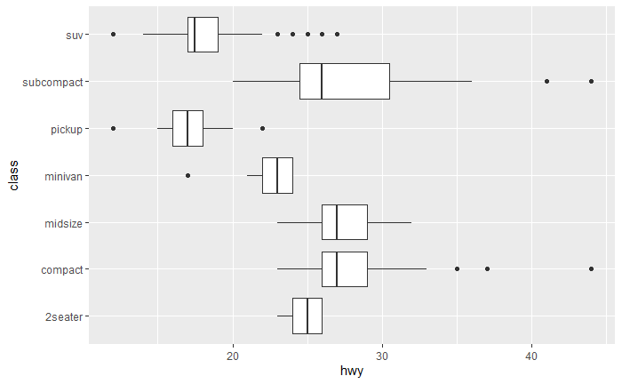

- coord quickmap = Sets aspect ratio correctly for maps (spartial data).

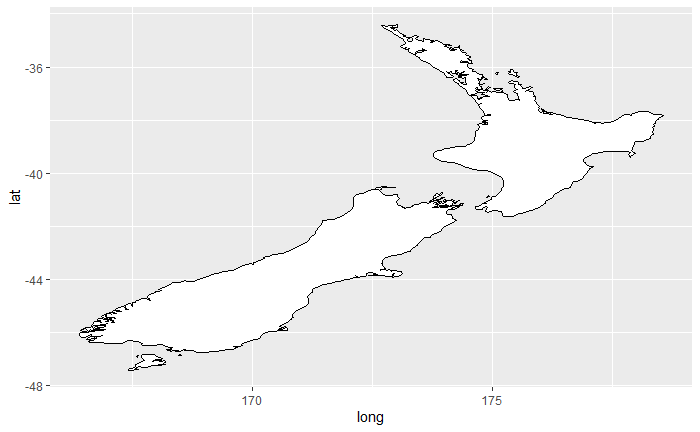

- Coords_polar = makes polar coordinate.

[figure not shown]

## 8.2 - Exercises

**1 - Turn a stacked bar chart into pie chart using coord_polar**

```r
bar <- ggplot(data = diamonds) +
  geom_bar(mapping = aes(x = cut, fill = cut), show.legend = FALSE, width = 1) +
  theme(aspect.ratio = 1) +
  labs(x = NULL, y = NULL)

bar + coord_flip()
bar + coord_polar()
```

[output not shown]

**2 - What does labs() do?**

Read the documentation.

Labs modifies axis legend and plot labels.

**3 - What’s the difference between coord_quickmap() and coord_map()?**

Quickmap is a approximation that does preserve straight lines.

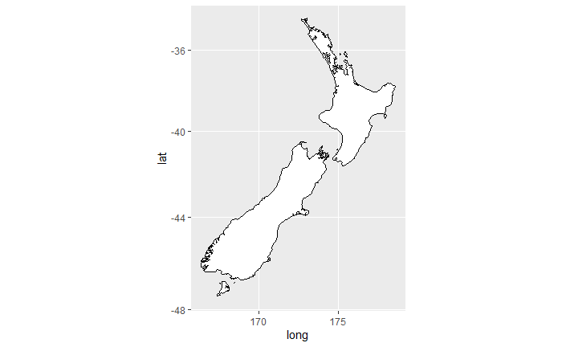

**4 - What does the following plot tell you? Why is coord_fixed important? And what does geom_abline() do?**

Plot:

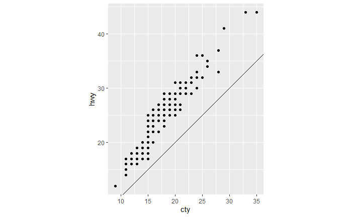

This plot tells us that there is a linear relationship between cty and hwy.

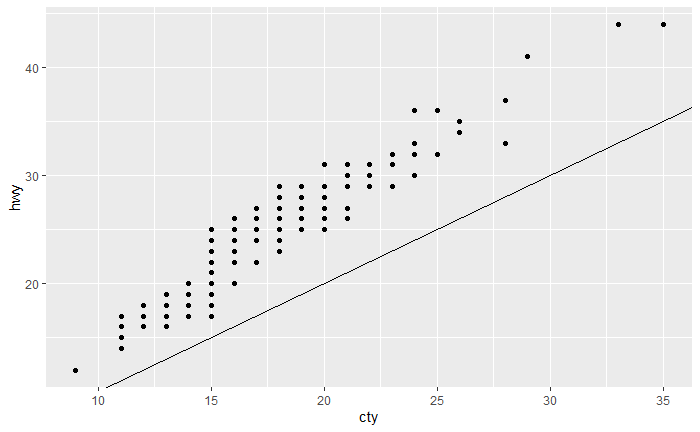

Without cord fixed, the x and y axis is no longer equal, making it somehwat more difficult to see. I.e. one unit on the x axis is one unit on the y axis when using coord_fixed().

```r
ggplot(data = mpg, mapping = aes(x = cty, y = hwy)) +
  geom_point() +
  coord_fixed()
```

[output not shown]

Geom_abline creates a refference line line.

# 9 - The layered grammer of graphics

## 9.1 - Notes

ggplot template:

```r
ggplot(date = <DATA>) +
  <GEOM>(mapping = aes(<MAPPINGS>), stat = <STAT>, position = <POSITION>) +
  <CORDINATE_FUNCTION> +
  <FACET_FUNCTION>
```

This template can build alllllll types of graphs!